# R Notebook

```r
#load necessary libraries
library(tidyverse)
library(dplyr)
library(readxl)
library(ggplot2)
library(ggpubr)
library(qqplotr)
#library(car)
library(e1071)
library(nortest)
library(BSDA)
# options("scipen"=100, "digits"=6)
library(reshape2)
```

# 12.34

## Do labels matter?

### A) Solution:

```r
n = c(130,248,174,68)
x = c(2.93,3.00,3.01,3.39)
df = data.frame(label = factor(c("Asian American", "Specific ethnicity", "Ethnicity American", "Other")), n = n, x = x)
df
```

| label | n | x |
| --- | --- | --- |
| Asian American | 130 | 2.93 |
| Specific ethnicity | 248 | 3.00 |
| Ethnicity American | 174 | 3.01 |
| Other | 68 | 3.39 |

```r
# Total sample size
N = sum(n)
# x bar
xbar =mean(x)
# number of categories
cat_num = length(unique(df$label)) # or nrow(df)
# Degree of freedom of numerator (groups)
dfg = cat_num - 1
paste("Degree of freedom of numerator (groups) is",dfg)
```

```
[1] "Degree of freedom of numerator (groups) is 3"
```

```r
# Degree of freedom of denominator (error)
dfe =  N - cat_num
paste("Degree of freedom of denominator (error) is",dfe)
```

```
[1] "Degree of freedom of denominator (error) is 616"
```

### B) Solution:

```r
df$"(x-xbar)^2" = (df$x - xbar)^2
df$"n(x-xbar)^2" = df$n * df$`(x-xbar)^2`
df
```

| label | n | x | (x-xbar)^2 | n(x-xbar)^2 |
| --- | --- | --- | --- | --- |
| Asian American | 130 | 2.93 | 0.02325625 | 3.0233125 |
| Specific ethnicity | 248 | 3.00 | 0.00680625 | 1.6879500 |
| Ethnicity American | 174 | 3.01 | 0.00525625 | 0.9145875 |
| Other | 68 | 3.39 | 0.09455625 | 6.4298250 |

```r
# sum of squares for groups
ssg = sum(df$`n(x-xbar)^2`)
ssg
```

```
[1] 12.05568
```

### C) Solution:

```r
# Here
sse = 797.25
# Mean square for groups
msg = ssg/dfg
msg
```

```
[1] 4.018558
```

```r
# Mean square for error
mse = sse/dfe
mse
```

```
[1] 1.294237
```

```r
# F-statistics
f = msg/mse
f
```

```
[1] 3.104963
```

### D) Solution:

```r
# Corresponding P-value for F statistics
pf(f, dfg, dfe, lower.tail = FALSE)
```

```
[1] 0.02611366
```

*Null hypothesis:* H0: means are equal *Alternate hypothesis:* H1: means are not equal *Since p value is less than the .05 significance level therefore we can reject the null hypothesis.*

### E) Solution:

*Even though the sample mean are pretty close to each other, due to the fact the sample sizes differ by a good margin, the means are not equal. It supports the conclusion obtained in part D.*

# 12.54

## A dandruff study.

### A) Solution:

```r
file_name = "ex12-54dandruff.xls"
df = read_xls(file_name)
```

```
* `` -> ...4
* `` -> ...5
```

```r
head(df)
```

| OBS | Treatment | Flaking | ...4 | ...5 | Pyrl | Keto | Placebo |
| --- | --- | --- | --- | --- | --- | --- | --- |
| 1 | PyrI | 17 | NA | NA | 17 | 17 | 30 |
| 2 | PyrI | 16 | NA | NA | 16 | 17 | 29 |
| 3 | PyrI | 18 | NA | NA | 18 | 17 | 31 |
| 4 | PyrI | 17 | NA | NA | 17 | 15 | 31 |
| 5 | PyrI | 18 | NA | NA | 18 | 14 | 29 |
| 6 | PyrI | 16 | NA | NA | 16 | 16 | 29 |

```r
summary(df)
```

```
      OBS         Treatment            Flaking        ...4           ...5              Pyrl           Keto          Placebo
 Min.   :  1.0   Length:355         Min.   :14.00   Mode:logical   Mode:logical   Min.   :14.0   Min.   :14.00   Min.   :26.00
 1st Qu.: 89.5   Class :character   1st Qu.:16.00   NA's:355       NA's:355       1st Qu.:16.0   1st Qu.:15.00   1st Qu.:28.00
 Median :178.0   Mode  :character   Median :17.00                                 Median :17.0   Median :16.00   Median :29.00
 Mean   :178.0                      Mean   :17.87                                 Mean   :17.3   Mean   :16.03   Mean   :29.39
 3rd Qu.:266.5                      3rd Qu.:18.00                                 3rd Qu.:18.0   3rd Qu.:17.00   3rd Qu.:31.00
 Max.   :355.0                      Max.   :32.00                                 Max.   :21.0   Max.   :18.00   Max.   :32.00
                                                                                  NA's   :134    NA's   :249     NA's   :327
```

```r
# df = df[-c(4,5)]
df = df[c(1,2,3)]
head(df)
```

| OBS | Treatment | Flaking |
| --- | --- | --- |
| 1 | PyrI | 17 |
| 2 | PyrI | 16 |
| 3 | PyrI | 18 |
| 4 | PyrI | 17 |
| 5 | PyrI | 18 |
| 6 | PyrI | 16 |

```r
# df = na.omit(df)
summary(df)
```

```
      OBS         Treatment            Flaking
 Min.   :  1.0   Length:355         Min.   :14.00
 1st Qu.: 89.5   Class :character   1st Qu.:16.00
 Median :178.0   Mode  :character   Median :17.00
 Mean   :178.0                      Mean   :17.87
 3rd Qu.:266.5                      3rd Qu.:18.00
 Max.   :355.0                      Max.   :32.00
```

```r
report = group_by(df, Treatment) %>%
  summarise(
    count = n(),
    mean = mean(Flaking, na.rm = TRUE),
    sd = sd(Flaking, na.rm = TRUE),
    se = sd(Flaking, na.rm = TRUE)/sqrt(n())
  ) %>% arrange(desc(count))
report
```

| Treatment | count | mean | sd | se |
| --- | --- | --- | --- | --- |
| PyrI | 112 | 17.39286 | 1.1418110 | 0.1078910 |
| PyrII | 109 | 17.20183 | 1.3524999 | 0.1295460 |
| Keto | 106 | 16.02830 | 0.9305149 | 0.0903796 |
| Placebo | 28 | 29.39286 | 1.5948827 | 0.3014045 |

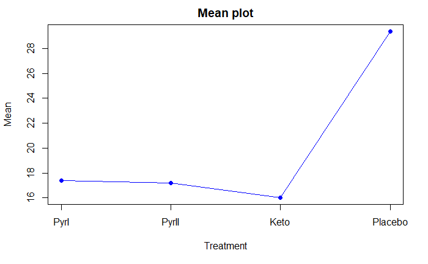

```r
plot(report$mean, xaxt="n", type = "o", main = "Mean plot", col = "blue", pch = 19, xlab = "Treatment", ylab = "Mean")
axis(1, at = seq(1, 4, 1), labels = report$Treatment)
```

### B) Solution:

*From the given data, H0 and H1 for ANOVA*

*H0: Population mean scores for four groups are same*

*H1: Population mean scores for four groups are not same*

```r
# one sample anova test
aov(Flaking~Treatment,df)
```

```
Call:
   aov(formula = Flaking ~ Treatment, data = df)

Terms:
                Treatment Residuals
Sum of Squares   4151.428   501.868
Deg. of Freedom         3       351

Residual standard error: 1.195752
Estimated effects may be unbalanced
```

```r
# ANOVA table
anova(aov(Flaking~Treatment,df))
```

```
Analysis of Variance Table

Response: Flaking
           Df Sum Sq Mean Sq F value    Pr(>F)
Treatment   3 4151.4 1383.81  967.82 < 2.2e-16 ***
Residuals 351  501.9    1.43
---
Signif. codes:  0 ‘***’ 0.001 ‘**’ 0.01 ‘*’ 0.05 ‘.’ 0.1 ‘ ’ 1
```

```r
# Total degree of freedom
sum(anova(aov(Flaking~Treatment,df))[1])
```

```
[1] 354
```

```r
# Total sum of squares
sum(anova(aov(Flaking~Treatment,df))[2])
```

```
[1] 4653.296
```

*Test statistics of ANOVA test, F = 967.82 . Degree of freedom for group is 3 and Degree of freedom for error is 351.*

*The P-value is almost zero which indicates a very strong evidence against H0.*

*So, not all means are same.*

# 13.43

## A comparison of plant species under low water conditions.

```r
file_name = "ex13-43plants1.xls"
df = read_xls(file_name, sheet = 2, range = cell_cols("A:D"))
head(df)
```

| obs | species | water | pctnit |
| --- | --- | --- | --- |
| 1 | 1 | 1 | 3.644 |
| 2 | 1 | 1 | 3.500 |
| 3 | 1 | 1 | 3.509 |
| 4 | 1 | 1 | 3.137 |
| 5 | 1 | 1 | 3.100 |
| 6 | 1 | 1 | 3.081 |

```r
df$species = as.factor(df$species)
df$water = as.factor(df$water)
summary(df)
```

```
      obs         species water      pctnit
 Min.   :  1.00   1:63    1:36   Min.   :0.719
 1st Qu.: 63.75   2:63    2:36   1st Qu.:1.643
 Median :126.50   3:63    3:36   Median :2.626
 Mean   :126.50   4:63    4:36   Mean   :2.403
 3rd Qu.:189.25           5:36   3rd Qu.:3.103
 Max.   :252.00           6:36   Max.   :3.958
                          7:36
```

```r
report = group_by(df, species,water) %>%
  summarise(
    # count = n(),
    mean = mean(pctnit, na.rm = TRUE),
    sd = sd(pctnit, na.rm = TRUE),
    # se = sd(pctnit, na.rm = TRUE)/sqrt(n())
  )# %>% arrange(desc(count))
report
```

| species | water | mean | sd |
| --- | --- | --- | --- |
| 1 | 1 | 3.2543333 | 0.22865859 |
| 1 | 2 | 2.7635556 | 0.06657348 |
| 1 | 3 | 2.8428889 | 0.23328761 |
| 1 | 4 | 2.9362222 | 0.07093444 |
| 1 | 5 | 3.0518889 | 0.09087690 |
| 1 | 6 | 3.0963333 | 0.08153680 |
| 1 | 7 | 3.3334444 | 0.24816784 |
| 2 | 1 | 2.4215556 | 0.16538675 |
| 2 | 2 | 2.0502222 | 0.14537003 |
| 2 | 3 | 2.0524444 | 0.14811829 |

[output cut: 18 more lines]

### A) Solution:

```r
# mean for each species by water
dcast(df, species~water, value.var='pctnit', mean)
```

| species | 1 | 2 | 3 | 4 | 5 | 6 | 7 |
| --- | --- | --- | --- | --- | --- | --- | --- |
| 1 | 3.254333 | 2.763556 | 2.842889 | 2.936222 | 3.051889 | 3.096333 | 3.3334444 |
| 2 | 2.421556 | 2.050222 | 2.052444 | 1.967333 | 1.956000 | 1.983889 | 2.2184444 |
| 3 | 3.058889 | 3.154111 | 3.200333 | 3.141889 | 3.395556 | 3.496111 | 3.5436667 |
| 4 | 1.423000 | 1.303667 | 1.125333 | 1.008667 | 1.258444 | 1.271222 | 0.9787778 |

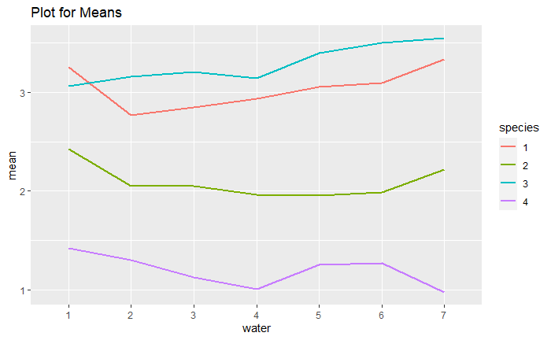

```r
ggplot(data = report) +
  geom_line(aes(x = water, y = mean, colour = species, group = species), lwd = 1) + ggtitle("Plot for Means")
```

*Means change across multiple species. So we can say that there is a main effect for species.*

*Means change across multiple water quantities. So we can say that there is a main effect for water*

*Plot for means patterns do not seem to be parallel. So we can assume that there is some kind of interaction.*

### B) Solution:

```r
# Standard deviation for each species by water
sd_df = dcast(df, species~water, value.var='pctnit', sd)
sd_df
```

| species | 1 | 2 | 3 | 4 | 5 | 6 | 7 |
| --- | --- | --- | --- | --- | --- | --- | --- |
| 1 | 0.2286586 | 0.06657348 | 0.2332876 | 0.07093444 | 0.0908769 | 0.08153680 | 0.2481678 |
| 2 | 0.1653868 | 0.14537003 | 0.1481183 | 0.22025667 | 0.1570995 | 0.28949760 | 0.1237822 |
| 3 | 0.1524946 | 0.33236330 | 0.2340951 | 0.29650567 | 0.2532642 | 0.34367261 | 0.3116220 |
| 4 | 0.1737613 | 0.26607518 | 0.1230173 | 0.13097996 | 0.2488590 | 0.07948707 | 0.2090262 |

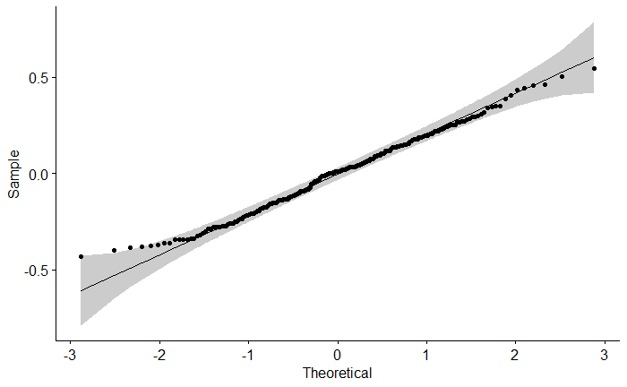

```r
# Build the linear model
model  <- lm(pctnit~species*water, data = df)
# Create a QQ plot of residuals
ggqqplot(residuals(model))
```

*In the QQ plot, as all the points fall approximately along the reference line, we can assume normality.*

###C) Solution:

```r
# two-way ANOVA test without interaction effect (NOT APPLICABLE IN THIS CASE)
# anova(aov(pctnit~species+water,df))
```

```r
# Two-way ANOVA with interaction effect
# anova(aov(pctnit~species*water, df))
anova(aov(pctnit~species+water + species:water,df))
```

```
Analysis of Variance Table

Response: pctnit
               Df  Sum Sq Mean Sq   F value    Pr(>F)
species         3 172.392  57.464 1301.3166 < 2.2e-16 ***
water           6   2.587   0.431    9.7628 1.486e-09 ***
species:water  18   4.745   0.264    5.9692 1.047e-11 ***
Residuals     224   9.891   0.044
---
Signif. codes:  0 ‘***’ 0.001 ‘**’ 0.01 ‘*’ 0.05 ‘.’ 0.1 ‘ ’ 1
```

*Null hypotheses:*

H0(species): main effect due to species is statistically insignificant.

H0(water): main effect due to water is statistically insignificant.

H0(interaction): interaction effect due to species and water is statistically insignificant.

*As all the P-values are less than .05 level of significance, we can reject all the null hypotheses and conclude main effects due to species and water as well as interaction are statistically significant.*